# Predicting Survival from Titanic Dataset

Chip Irek

# Problem statement

#### Competition Description

The sinking of the RMS Titanic is one of the most infamous shipwrecks in history. On April 15, 1912, during her maiden voyage, the Titanic sank after colliding with an iceberg, killing 1502 out of 2224 passengers and crew. This sensational tragedy shocked the international community and led to better safety regulations for ships.

One of the reasons that the shipwreck led to such loss of life was that there were not enough lifeboats for the passengers and crew. Although there was some element of luck involved in surviving the sinking, some groups of people were more likely to survive than others, such as women, children, and the upper-class.

In this challenge, we ask you to complete the analysis of what sorts of people were likely to survive. In particular, we ask you to apply the tools of machine learning to predict which passengers survived the tragedy.

#### Data dictionary

survival - Survival (0 = No; 1 = Yes) class - Passenger Class (1 = 1st; 2 = 2nd; 3 = 3rd) name - Name sex - Sex age - Age sibsp - Number of Siblings/Spouses Aboard parch - Number of Parents/Children Aboard ticket - Ticket Number fare - Passenger Fare cabin - Cabin embarked - Port of Embarkation (C = Cherbourg; Q = Queenstown; S = Southampton)

# Exploratory Data Analysis

```r
options(warn=-1)
library(elasticnet)
library(caret)
library(plyr)
library(dplyr)
library(skimr)
library(RANN)
library(e1071)
library(PerformanceAnalytics)
library(outliers)
library(xgboost)
library(ranger)
library(mice)
library(DataExplorer)

set.seed(1)

training.dataset <- read.csv("train.csv", stringsAsFactors=FALSE, na.strings = c("","NaN"," "))
test.dataset  <- read.csv("test.csv",  stringsAsFactors=FALSE, na.strings = c("","NaN"," "))
```

```r
#create_report(training.dataset, output_file = "eda_pre_cleaning.html")
```

```r
str(training.dataset)
```

```
## 'data.frame':    891 obs. of  12 variables:
##  $ PassengerId: int  1 2 3 4 5 6 7 8 9 10 ...
##  $ Survived   : int  0 1 1 1 0 0 0 0 1 1 ...
##  $ Pclass     : int  3 1 3 1 3 3 1 3 3 2 ...
##  $ Name       : chr  "Braund, Mr. Owen Harris" "Cumings, Mrs. John Bradley (Florence Briggs Thayer)" "Heikkinen, Miss. Laina" "Futrelle, Mrs. Jacques Heath (Lily May Peel)" ...
##  $ Sex        : chr  "male" "female" "female" "female" ...
##  $ Age        : num  22 38 26 35 35 NA 54 2 27 14 ...
##  $ SibSp      : int  1 1 0 1 0 0 0 3 0 1 ...
##  $ Parch      : int  0 0 0 0 0 0 0 1 2 0 ...
##  $ Ticket     : chr  "A/5 21171" "PC 17599" "STON/O2. 3101282" "113803" ...
##  $ Fare       : num  7.25 71.28 7.92 53.1 8.05 ...
##  $ Cabin      : chr  NA "C85" NA "C123" ...
##  $ Embarked   : chr  "S" "C" "S" "S" ...
```

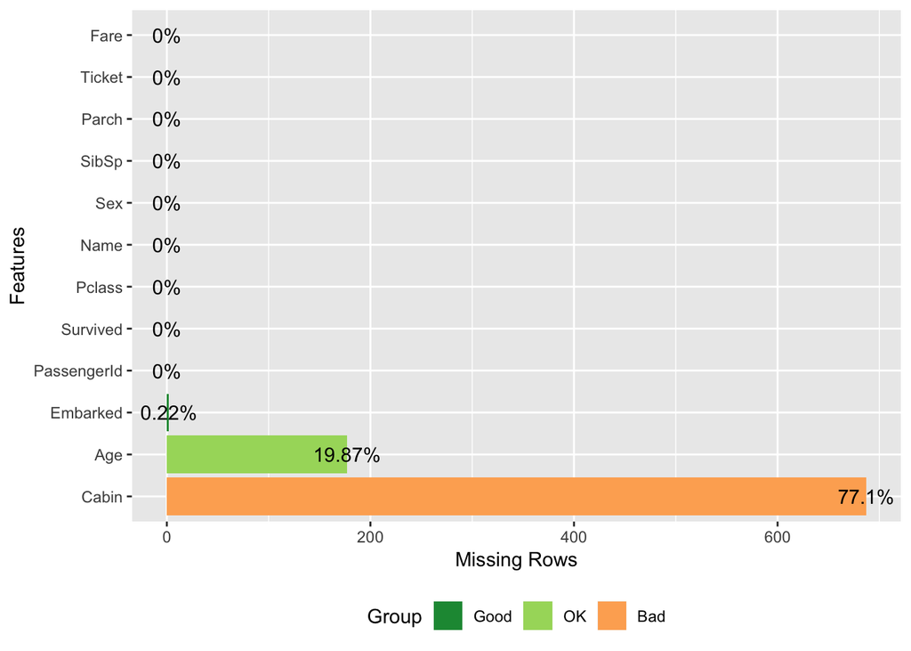

```r
plot_missing(training.dataset)
```

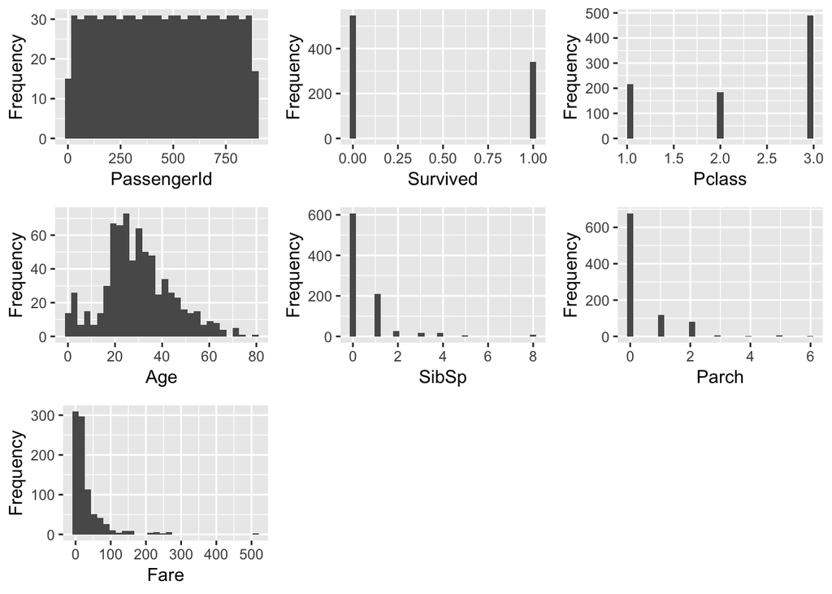

```r
plot_histogram(training.dataset)
```

```
## 3 columns ignored with more than 50 categories.
## Name: 891 categories
## Ticket: 681 categories
## Cabin: 148 categories
```

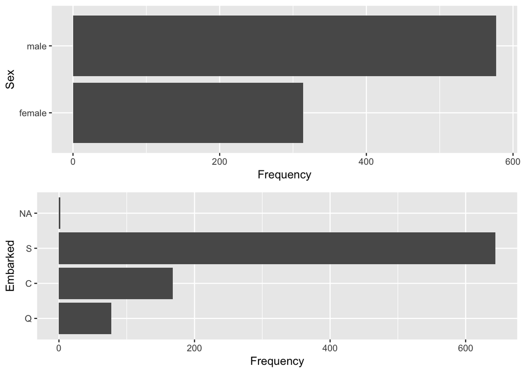

```r
plot_bar(training.dataset)
```

```
## 3 features with more than 20 categories ignored!
## Name: 891 categories
## Ticket: 681 categories
## Cabin: 148 categories
```

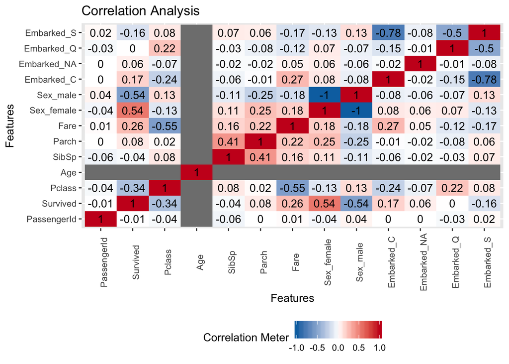

```r
plot_correlation(training.dataset, title="Correlation Analysis")
```

# Cleaning the data

#### Outliers?

- None.

#### Unbalanced data?

- None.

#### Useless fields?

- *PassengerID* and *Name* and *Ticket* are unique identifiers and hold no information for this study, and will be removed.

```r
# reclass target variable
training.dataset$Survived <- ifelse(training.dataset$Survived == '0', 'No', 'Yes')
training.dataset$Survived <- as.factor(training.dataset$Survived)
```

```r
# remove the 3 id fields and the useless Cabin field
training.dataset <- training.dataset %>%
  select(-c('PassengerId', 'Name', 'Ticket', 'Cabin')) %>%
  filter(!is.na(training.dataset$Embarked))
```

```r
# convert to factors
training.dataset$Pclass <- as.factor(training.dataset$Pclass)
training.dataset$Sex <- as.factor(training.dataset$Sex)
training.dataset$Embarked <- as.factor(training.dataset$Embarked)
```

```r
# impute mean age where NA
training.dataset$Age[is.na(training.dataset$Age)] <- mean(training.dataset$Age, na.rm=TRUE)
```

```r
str(training.dataset)
```

```
## 'data.frame':    889 obs. of  8 variables:
##  $ Survived: Factor w/ 2 levels "No","Yes": 1 2 2 2 1 1 1 1 2 2 ...
##  $ Pclass  : Factor w/ 3 levels "1","2","3": 3 1 3 1 3 3 1 3 3 2 ...
##  $ Sex     : Factor w/ 2 levels "female","male": 2 1 1 1 2 2 2 2 1 1 ...
##  $ Age     : num  22 38 26 35 35 ...
##  $ SibSp   : int  1 1 0 1 0 0 0 3 0 1 ...
##  $ Parch   : int  0 0 0 0 0 0 0 1 2 0 ...
##  $ Fare    : num  7.25 71.28 7.92 53.1 8.05 ...
##  $ Embarked: Factor w/ 3 levels "C","Q","S": 3 1 3 3 3 2 3 3 3 1 ...
```

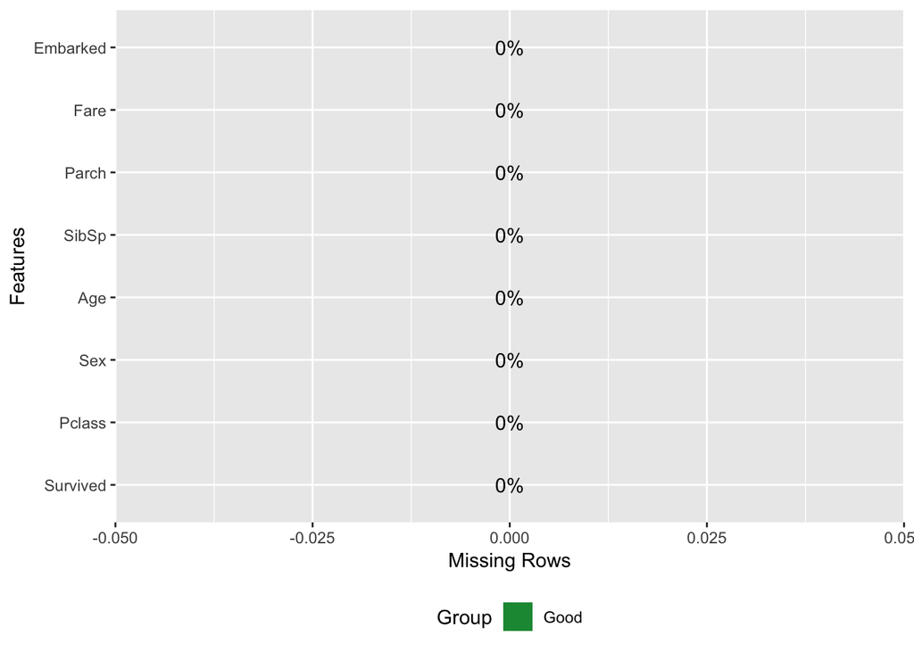

```r
plot_missing(training.dataset)
```

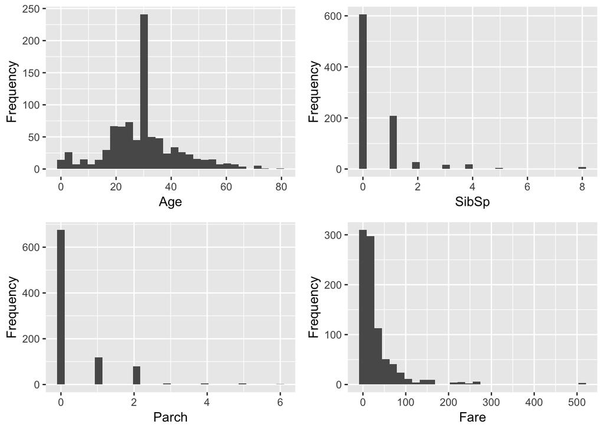

```r
plot_histogram(training.dataset)
```

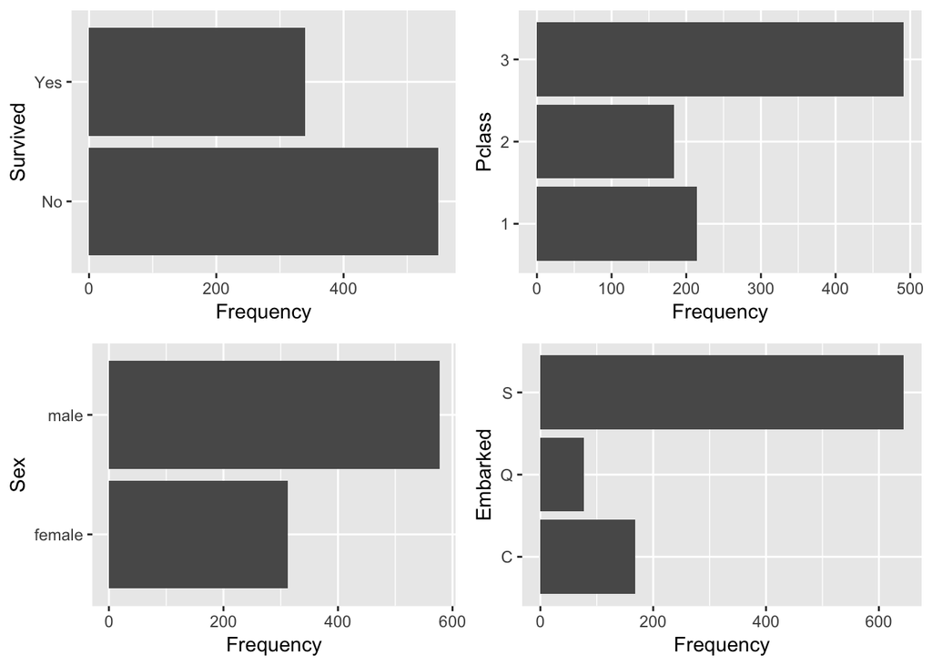

```r
plot_bar(training.dataset, order_bar=FALSE)
```

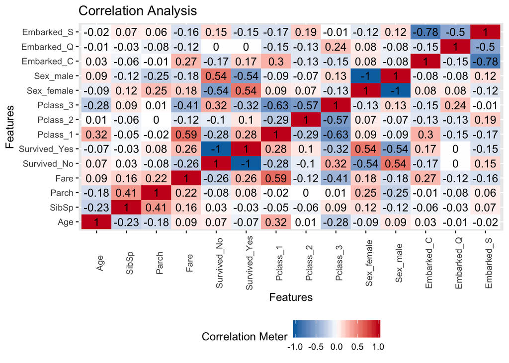

```r
plot_correlation(training.dataset, title="Correlation Analysis")
```

# Observations about the data

# Train models RF, SVM, kNN, and XGBoost

```r
fit.control <- trainControl(
    method = 'cv',                   # k-fold cross validation
    number = 5,
    savePredictions = 'final',       # saves predictions for optimal tuning parameter
    classProbs = T#,                 # should class probabilities be returned
)
```

```r
# train random forest
model.rf = train(Survived ~ .,
                 data=training.dataset,
                 method='rf',
                 tuneLength=10,
                 trControl=fit.control)
model.rf
```

```
## Random Forest
##
## 889 samples
##   7 predictor
##   2 classes: 'No', 'Yes'
##
## No pre-processing
## Resampling: Cross-Validated (5 fold)
## Summary of sample sizes: 711, 711, 711, 711, 712
## Resampling results across tuning parameters:
##
##   mtry  Accuracy   Kappa
##   2     0.8301847  0.6218764
##   3     0.8369517  0.6452517
##   4     0.8335936  0.6406394
##   5     0.8257094  0.6256630
##   6     0.8178252  0.6105367
##   7     0.8155907  0.6072795
##   8     0.8110836  0.5981677
##   9     0.8133244  0.6026581
##
## Accuracy was used to select the optimal model using the largest value.
## The final value used for the model was mtry = 3.
```

```r
# train SVM
model.svm = train(Survived ~ .,
                  data=training.dataset,
                  method='svmRadial',
                  tuneLength=10,
                  trControl=fit.control)
model.svm
```

```
## Support Vector Machines with Radial Basis Function Kernel
##
## 889 samples
##   7 predictor
##   2 classes: 'No', 'Yes'
##
## No pre-processing
## Resampling: Cross-Validated (5 fold)
## Summary of sample sizes: 711, 711, 711, 711, 712
## Resampling results across tuning parameters:
##
##   C       Accuracy   Kappa
##     0.25  0.8098965  0.5808197
##     0.50  0.8155145  0.5919698
##     1.00  0.8188980  0.5994389
##     2.00  0.8177553  0.5977911
##     4.00  0.8143909  0.5900432
##     8.00  0.8110074  0.5840470
##    16.00  0.8031296  0.5686459
##    32.00  0.8020123  0.5660571
##    64.00  0.7986225  0.5586561
##   128.00  0.8008697  0.5612725
##
## Tuning parameter 'sigma' was held constant at a value of 0.1214131
## Accuracy was used to select the optimal model using the largest value.
## The final values used for the model were sigma = 0.1214131 and C = 1.
```

```r
# train k-nearest neighbors
model.knn = train(Survived ~ .,
                  data=training.dataset,
                  method='knn',
                  tuneLength=10,
                  trControl=fit.control)
model.knn
```

```
## k-Nearest Neighbors
##
## 889 samples
##   7 predictor
##   2 classes: 'No', 'Yes'
##
## No pre-processing
## Resampling: Cross-Validated (5 fold)
## Summary of sample sizes: 711, 712, 711, 711, 711
## Resampling results across tuning parameters:
##
##   k   Accuracy   Kappa
##    5  0.7086523  0.3716691
##    7  0.7052815  0.3610622
##    9  0.6951501  0.3363257
##   11  0.6974291  0.3384099
##   13  0.7041706  0.3537867
##   15  0.6917666  0.3159398
##   17  0.6906367  0.3080954
##   19  0.7007745  0.3278980
##   21  0.7063924  0.3355123
##   23  0.7075224  0.3401419
##
## Accuracy was used to select the optimal model using the largest value.
## The final value used for the model was k = 5.
```

```r
# train xgboost

# setup the xgb tune grid
tune.grid.for.xgb <- expand.grid(nrounds          = c(10,50),
                                 max_depth        = c(5, 10, 15),
                                 eta              = c(0.01, 0.001, 0.0001),
                                 gamma            = c(1, 2, 3),
                                 colsample_bytree = c(0.4, 0.7, 1.0),
                                 min_child_weight = c(0.5, 1, 1.5),
                                 subsample        = 1
)

model.xgb <- train(Survived ~.,
                   data=training.dataset,
                   method="xgbTree",
                   trControl=fit.control,
                   tuneGrid=tune.grid.for.xgb
                   )
model.xgb
```

```
## eXtreme Gradient Boosting
##
## 889 samples
##   7 predictor
##   2 classes: 'No', 'Yes'
##
## No pre-processing
## Resampling: Cross-Validated (5 fold)
## Summary of sample sizes: 711, 712, 711, 711, 711
## Resampling results across tuning parameters:
##
##   eta    max_depth  gamma  colsample_bytree  min_child_weight  nrounds
##   1e-04   5         1      0.4               0.5               10
##   1e-04   5         1      0.4               0.5               50
##   1e-04   5         1      0.4               1.0               10
##   1e-04   5         1      0.4               1.0               50
##   1e-04   5         1      0.4               1.5               10
##   1e-04   5         1      0.4               1.5               50
##   1e-04   5         1      0.7               0.5               10
##   1e-04   5         1      0.7               0.5               50
##   1e-04   5         1      0.7               1.0               10
##   1e-04   5         1      0.7               1.0               50
##   1e-04   5         1      0.7               1.5               10
##   1e-04   5         1      0.7               1.5               50
##   1e-04   5         1      1.0               0.5               10
##   1e-04   5         1      1.0               0.5               50
##   1e-04   5         1      1.0               1.0               10
##   1e-04   5         1      1.0               1.0               50
##   1e-04   5         1      1.0               1.5               10
##   1e-04   5         1      1.0               1.5               50
##   1e-04   5         2      0.4               0.5               10
##   1e-04   5         2      0.4               0.5               50
##   1e-04   5         2      0.4               1.0               10
##   1e-04   5         2      0.4               1.0               50
##   1e-04   5         2      0.4               1.5               10
##   1e-04   5         2      0.4               1.5               50
##   1e-04   5         2      0.7               0.5               10
##   1e-04   5         2      0.7               0.5               50
##   1e-04   5         2      0.7               1.0               10
##   1e-04   5         2      0.7               1.0               50
```

[output cut: 936 more lines]

```
##   0.8177490  0.6008405
##   0.8087602  0.5856539
##   0.8132546  0.5921848
##   0.8098902  0.5890927
##   0.8188789  0.6071670
##   0.8222561  0.6133168
##   0.8256269  0.6188114
##   0.8222561  0.6119351
##   0.8244906  0.6166633
##
## Tuning parameter 'subsample' was held constant at a value of 1
## Accuracy was used to select the optimal model using the largest value.
## The final values used for the model were nrounds = 50, max_depth = 10,
##  eta = 0.01, gamma = 3, colsample_bytree = 1, min_child_weight = 1
##  and subsample = 1.
```

# Evaluate the models

```r
# compare model performances using resample()
models.compared <- resamples(list(`Random Forest`=model.rf,
                                  `SVM`=model.svm,
                                  `kNN`=model.knn,
                                  `XGBoost`=model.xgb
                                  ))

# summary of the models performances
summary(models.compared)
```

```
##
## Call:
## summary.resamples(object = models.compared)
##
## Models: Random Forest, SVM, kNN, XGBoost
## Number of resamples: 5
##
## Accuracy
##                    Min.   1st Qu.    Median      Mean   3rd Qu.      Max.
## Random Forest 0.7528090 0.8146067 0.8539326 0.8369517 0.8764045 0.8870056
## SVM           0.7808989 0.8089888 0.8192090 0.8188980 0.8426966 0.8426966
## kNN           0.6910112 0.7005650 0.7022472 0.7086523 0.7191011 0.7303371
## XGBoost       0.8079096 0.8202247 0.8258427 0.8278741 0.8314607 0.8539326
##               NA's
## Random Forest    0
## SVM              0
## kNN              0
## XGBoost          0
##
## Kappa
##                    Min.   1st Qu.    Median      Mean   3rd Qu.      Max.
## Random Forest 0.4705246 0.5900907 0.6835339 0.6452517 0.7291090 0.7530003
## SVM           0.5155618 0.5635997 0.6136426 0.5994389 0.6511758 0.6532146
## kNN           0.3324697 0.3546812 0.3640286 0.3716691 0.3914114 0.4157549
## XGBoost       0.5776842 0.5989862 0.6215883 0.6225403 0.6327373 0.6817056
##               NA's
## Random Forest    0
## SVM              0
## kNN              0
## XGBoost          0
```

# More feature engineering

#### Reload the data and apply what’s already been engineered

```r
training.dataset <- read.csv("train.csv", stringsAsFactors=FALSE, na.strings = c("","NaN"," "))

# reclass target variable
training.dataset$Survived <- ifelse(training.dataset$Survived == '0', 'No', 'Yes')
training.dataset$Survived <- as.factor(training.dataset$Survived)
```

```r
# remove the 3 id fields and the useless Cabin field
training.dataset <- training.dataset %>%
  select(-c('PassengerId', 'Name', 'Ticket', 'Cabin')) %>%
  filter(!is.na(training.dataset$Embarked))
```

```r
# convert to factors
training.dataset$Pclass <- as.factor(training.dataset$Pclass)
training.dataset$Sex <- as.factor(training.dataset$Sex)
training.dataset$Embarked <- as.factor(training.dataset$Embarked)
```

#### Add feature “family size”

```r
training.dataset$FamilySize <- training.dataset$Parch + training.dataset$SibSp

training.dataset <- training.dataset %>%
  select(-c('Parch', 'SibSp'))
```

#### Impute Age better using MICE

```r
summary(training.dataset$Age)
```

```
##    Min. 1st Qu.  Median    Mean 3rd Qu.    Max.    NA's
##    0.42   20.00   28.00   29.64   38.00   80.00     177
```

```r
mi <- mice(training.dataset)
training.dataset <- complete(mi)
```

```r
summary(training.dataset$Age)
```

```
##    Min. 1st Qu.  Median    Mean 3rd Qu.    Max.
##    0.42   21.00   28.50   30.06   39.00   80.00
```

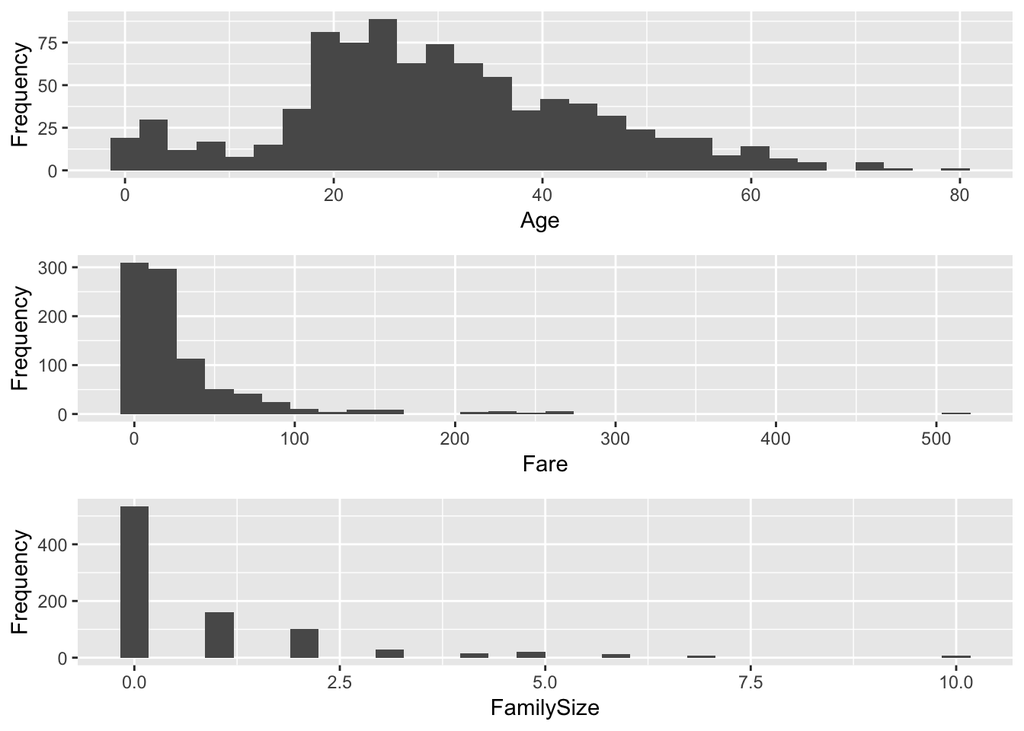

```r
plot_histogram(training.dataset)
```

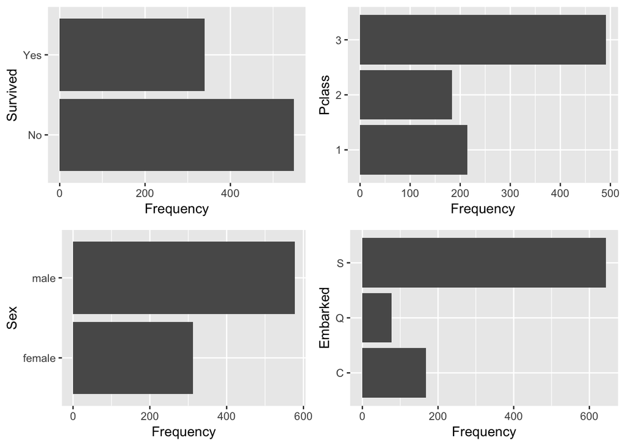

```r
plot_bar(training.dataset, order_bar=FALSE)
```

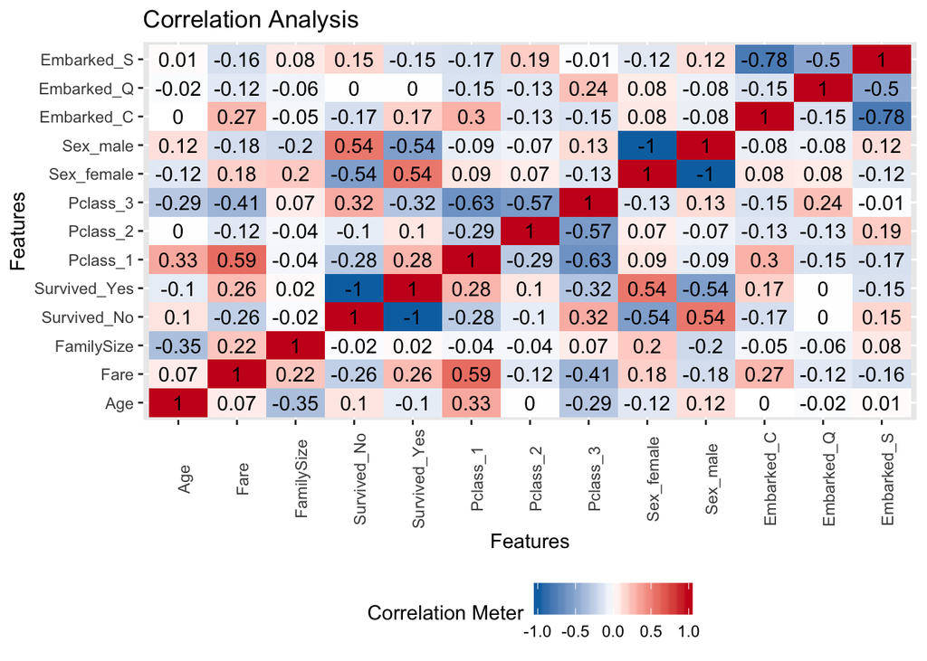

```r
plot_correlation(training.dataset, title="Correlation Analysis")
```

#### Re-run models and evaluate

```r
# train random forest
model.rf = train(Survived ~ .,
                 data=training.dataset,
                 method='rf',
                 tuneLength=10,
                 trControl=fit.control)
```

```r
# train SVM
model.svm = train(Survived ~ .,
                  data=training.dataset,
                  method='svmRadial',
                  tuneLength=10,
                  trControl=fit.control)

# train k-nearest neighbors
model.knn = train(Survived ~ .,
                  data=training.dataset,
                  method='knn',
                  tuneLength=10,
                  trControl=fit.control)

# train xgb
model.xgb <- train(Survived ~.,
                   data=training.dataset,
                   method="xgbTree",
                   trControl=fit.control,
                   tuneGrid=tune.grid.for.xgb
                   )

# compare model performances using resample()
models.compared <- resamples(list(`Random Forest`=model.rf,
                                  `SVM`=model.svm,
                                  `kNN`=model.knn,
                                  `XGBoost`=model.xgb
                                  ))

# summary of the models performances
summary(models.compared)
```

```
##
## Call:
## summary.resamples(object = models.compared)
##
## Models: Random Forest, SVM, kNN, XGBoost
## Number of resamples: 5
##
## Accuracy
##                    Min.   1st Qu.    Median      Mean   3rd Qu.      Max.
## Random Forest 0.7977528 0.8146067 0.8305085 0.8368882 0.8707865 0.8707865
## SVM           0.7584270 0.7966102 0.8426966 0.8211198 0.8539326 0.8539326
## kNN           0.6853933 0.7078652 0.7359551 0.7278106 0.7514124 0.7584270
## XGBoost       0.8089888 0.8146067 0.8248588 0.8402527 0.8707865 0.8820225
##               NA's
## Random Forest    0
## SVM              0
## kNN              0
## XGBoost          0
##
## Kappa
##                    Min.   1st Qu.    Median      Mean   3rd Qu.      Max.
## Random Forest 0.5434597 0.6040178 0.6336921 0.6439311 0.7192429 0.7192429
## SVM           0.4563148 0.5395954 0.6572215 0.6033043 0.6798561 0.6835339
## kNN           0.3104593 0.3405529 0.4092642 0.3952926 0.4503106 0.4658758
## XGBoost       0.5813503 0.5948407 0.6182425 0.6524343 0.7255664 0.7421713
##               NA's
## Random Forest    0
## SVM              0
## kNN              0
## XGBoost          0
```

# Conclusion - Acheived accuracy of 84% using tuned XGBoost

# Submission

#### Apply feature engineering to the test dataset

```r
test.dataset <- read.csv("test.csv", stringsAsFactors=FALSE, na.strings = c("","NaN"," "))
```

```r
# remove the 3 id fields and the useless Cabin field
test.dataset <- test.dataset %>%
  #select(-c('PassengerId', 'Name', 'Ticket', 'Cabin')) %>%
  filter(!is.na(test.dataset$Embarked))
```

```r
# convert to factors
test.dataset$Pclass   <- as.factor(test.dataset$Pclass)
test.dataset$Sex      <- as.factor(test.dataset$Sex)
test.dataset$Embarked <- as.factor(test.dataset$Embarked)
```

```r
# add feature 'family size'
test.dataset$FamilySize <- test.dataset$Parch + test.dataset$SibSp

test.dataset <- test.dataset %>%
  select(-c('Parch', 'SibSp'))
```

```r
# impute age using MICE
mi <- mice(test.dataset)
test.dataset <- complete(mi)
```

#### Run the prediction and build the submission file

```r
# use the test dataset and the model and generate the predictions
test.dataset$Survived <- predict(model.xgb, newdata=test.dataset, type="raw")

# since we made this a factor, and the competition requires 0 or 1, convert the data from factors to numbers
test.dataset$Survived <- ifelse(test.dataset$Survived == 'No', 0, 1)

# build the output csv file
write.csv(test.dataset[,c("PassengerId", "Survived")], file="predictions.csv", row.names=FALSE, quote=FALSE)
```